# Lecturer Questions: Comparison with Paoletti et al. (2018)

George Kinnear

17/11/2021

```r
library(tidyverse)
library(janitor)

# Tables
library(knitr)
library(kableExtra)
basic_kable = function(df, ...) {
  df %>%
    kable(...) %>%
    kable_styling(bootstrap_options = "striped", full_width = F)
}

# Plot styling
theme_set(theme_minimal())
```

# Paoletti et al. (2018) data

This data comes from the table in the supplementary materials posted online. We use it to replicate some of the results in Table 3 of the 2018 ESM paper, and visualise the distributions of the number of questions observed in each category.

```r
paoletti_data = read_csv("data/paoletti_table3_data.csv")
paoletti_data %>%
  kable(booktabs = T) %>%
  kable_styling(full_width = F)
```

| Lecturer | Fact | Next step | Proof framework | Warrant | Evaluation | Convention | Other | Total |
| --- | --- | --- | --- | --- | --- | --- | --- | --- |
| L1 | 12 | 4 | 2 | 4 | 4 | 11 | 7 | 44 |
| L2 | 21 | 23 | 12 | 10 | 1 | 1 | 13 | 81 |
| L3 | 29 | 8 | 0 | 12 | 2 | 1 | 1 | 53 |
| L4 | 41 | 8 | 0 | 1 | 1 | 3 | 1 | 55 |
| L5 | 18 | 1 | 0 | 3 | 7 | 2 | 1 | 32 |
| L6 | 7 | 3 | 3 | 5 | 0 | 0 | 0 | 18 |
| L7 | 64 | 5 | 0 | 5 | 4 | 1 | 8 | 87 |
| L8 | 81 | 55 | 13 | 19 | 9 | 7 | 18 | 202 |
| L9 | 8 | 6 | 0 | 2 | 2 | 1 | 7 | 26 |
| L10 | 0 | 0 | 1 | 1 | 0 | 0 | 2 | 4 |
| L11 | 8 | 4 | 0 | 0 | 4 | 0 | 1 | 17 |

```r
paoletti_code_counts = paoletti_data %>%
  pivot_longer(
    cols = !Lecturer,
    names_to = "code_name",
    values_to = "num_q"
  )

paoletti_code_counts %>%
  group_by(code_name) %>%
  summarise(
    mean_count = mean(num_q),
    sd = sd(num_q),
    median = median(num_q),
    max = max(num_q),
    min = min(num_q)
  ) %>%
  arrange(ifelse(code_name=="Total",1, 0), -mean_count) %>%
  kable(booktabs = T, digits = 1) %>%
  kable_styling(full_width = F)
```

| code_name | mean_count | sd | median | max | min |
| --- | --- | --- | --- | --- | --- |
| Fact | 26.3 | 25.8 | 18 | 81 | 0 |
| Next step | 10.6 | 15.9 | 5 | 55 | 0 |
| Warrant | 5.6 | 5.8 | 4 | 19 | 0 |
| Other | 5.4 | 5.9 | 2 | 18 | 0 |
| Evaluation | 3.1 | 2.9 | 2 | 9 | 0 |
| Proof framework | 2.8 | 4.9 | 0 | 13 | 0 |
| Convention | 2.5 | 3.5 | 1 | 11 | 0 |
| Total | 56.3 | 55.0 | 44 | 202 | 4 |

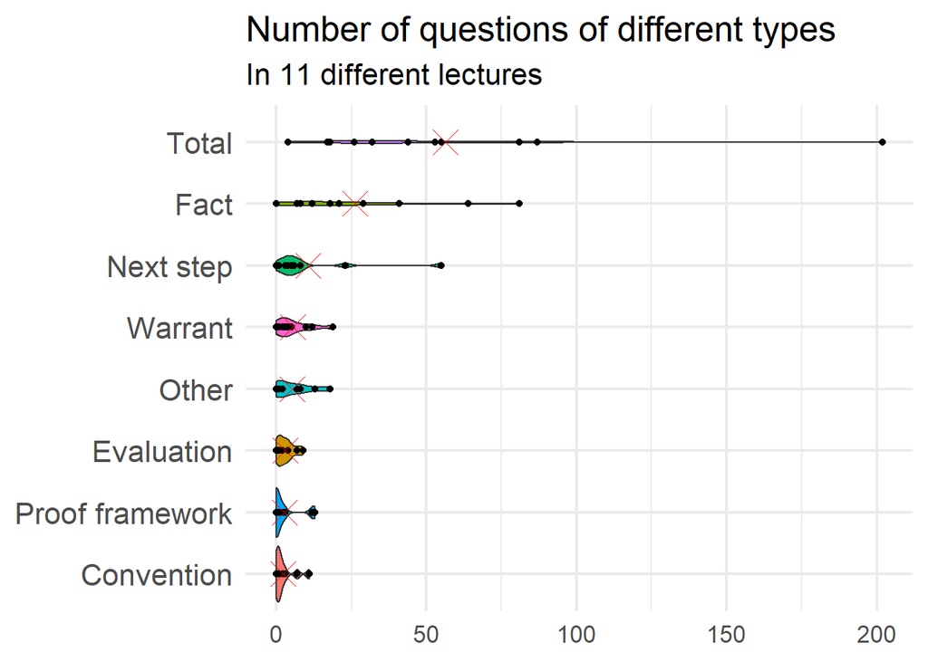

```r
paoletti_code_counts %>%
  ggplot(aes(x = fct_reorder(code_name, num_q, .fun = mean, .desc = FALSE),
             y = num_q)) +
  aes(fill = code_name) +
  geom_violin() +
  geom_point() +
  #geom_boxplot(alpha = 0.5, width = 0.3, fill = "white") +
  stat_summary(fun=mean, geom="point", shape=4, size=6, colour = "red", position = position_nudge(x = 0))+
    coord_flip() +
  theme_minimal(base_size = 16) +
  theme(strip.text=element_text(size=22),
        axis.text.x=element_text(angle=0),
        axis.text.y=element_text(size=16),
        legend.position = "none") +
  labs(title = "Number of questions of different types",
       subtitle = "In 11 different lectures",
       y = NULL,
       x = NULL)
```

# Comparable data from our study

Here we load all the data, but then restrict to those courses we have deemed most in line with the “advanced mathematics” course type studied by Paoletti et al.

```r
all_qs_all_lecs <- read_csv("data/ANON_LQ_Maths_All.csv")
anon_courses <- read_csv("data/ANON_courses.csv")

codes <- c("A", "C", "E", "F", "N", "O", "P", "U", "W", "X")
# Collapsing C, P, X, O into Other
collapsed_codes <- c("A", "O", "E", "F", "N", "O", "O", "U", "W", "O")

code_names <- c("Admin", "Convention", "Evaluation", "Fact", "Next step", "Other",
                "Proof framework", "Understanding check", "Warrant", "Example generation")

code_details <- tibble(code = codes, code_name = code_names) %>%
  mutate(
    collapsed_code = case_when(
      code %in% c("C", "P", "X", "O") ~ "Other",
      TRUE ~ code_name
    )
  ) %>%
  add_row(
    code = "Total",
    code_name = "Total",
    collapsed_code = "Total"
  )

all_qs_advanced <- all_qs_all_lecs %>%
  # restrict to only those courses that were deemed "advanced mathematics"
  semi_join(
    anon_courses %>% filter(advanced == "yes"),
    by = c("course" = "anon_code")
  )
```

```r
# Making list of all lectures and category code combos
lec_cat <- expand_grid(
  all_qs_advanced %>% select(course, session) %>% distinct(),
  category = codes
)
```

These are the courses that we focus on:

```r
course_demographics <- anon_courses %>%
  filter(advanced == "yes") %>%
  left_join(all_qs_all_lecs %>% select(course, session) %>% distinct(), by = c("anon_code" = "course")) %>%
  group_by(anon_course) %>%
  summarise(
    course_level = first(course_level),
    course_topic = first(course_topic),
    room_capacity = max(room_cap),
    num_lecturers = n_distinct(anon_lec),
    num_lectures = n(),
    .groups = "drop"
  ) %>%
  separate(course_level, into = c("M_or_E", "year"), sep = 1)  %>%
  select(
    year,
    course_code = anon_course,
    course_topic,
    room_capacity,
    num_lecturers,
    num_lectures
  ) %>%
  mutate(
    room_capacity_approx = round(room_capacity/25, digits = 0)*25
  ) %>%
  relocate(room_capacity_approx, .after = room_capacity) %>%
  arrange(year, -room_capacity, -num_lectures, -num_lecturers, course_topic)

course_demographics %>%
  select(-room_capacity) %>%
  rename(
    "Year" = year,
    "Course code" = course_code,
    "Topic" = course_topic,
    "Room capacity (approx.)" = room_capacity_approx,
    "Number of lecturers" = num_lecturers,
    "Number of lectures" = num_lectures
  ) %>%
  adorn_totals(c("row")) %>%
  kable(booktabs = T) %>%
  kable_styling(full_width = F) %>%
  collapse_rows(columns = 1, latex_hline = "major", valign = "top")
```

Year

Course code

Topic

Room capacity (approx.)

Number of lecturers

Number of lectures

1

1C

Linear algebra

350

4

40

1D

Pure mathematics

200

2

8

2

2B

Pure mathematics

325

3

12

3

3A

Algebra

200

1

4

3B

Complex analysis

200

1

4

4

4A

Group theory

100

1

4

Total

1375

12

72

```r
count_qs_by_cat <- all_qs_advanced %>%
  mutate(
    lecture = paste(course, session)
  ) %>%
  tabyl(lecture, category) %>%
  select(-"NA_") %>%
  separate(
    col = lecture,
    into = c("course", "session"),
    sep = " "
  ) %>%
  adorn_totals(c("col"))

counts_by_lecture <- all_qs_advanced %>%
  filter(!is.na(category)) %>%
  group_by(course, session, category) %>%
  summarise(
    num_q = sum(!is.na(category)),
    num_sr = sum(student_response == "Y"),
    num_po = sum(student_response == "Y" | wait_time >= 3),
    .groups = "drop"
  ) %>%
  # make sure lectures with no questions are included, with counts of 0
  full_join(lec_cat, by = c("course", "session", "category")) %>%
  mutate_all(~replace(., is.na(.), 0)) %>%
  # tidy up the columns, including replacing category codes with names
  arrange(course, session, category) %>%
  left_join(code_details, by = c("category" = "code")) %>%
  select(code_name, everything(), -collapsed_code, -category)
```

```r
# Add totals for each course/session combo
# NB - this was a possible alternative approach
# https://community.rstudio.com/t/getting-summary-by-group-and-overall-using-tidyverse/54656/6

add_group_totals <- function(df) {
  df %>%
    # Add rows containing the totals
    bind_rows(
      df %>%
        group_by(course, session) %>%
        summarise(across(contains("num_"), sum), .groups = "drop_last") %>%
        mutate(code_name = "Total")
    ) %>%
    # Put the totals at the end of each group (just for neatness)
    mutate(is_total = code_name=="Total") %>%
    arrange(course, session, is_total, code_name) %>%
    select(-is_total)
}

produce_summary_table <- function(df) {
  df %>%
    group_by(code_name) %>%
    summarise(across(contains("num_"), list(mean = mean, sd = sd)), .groups = "drop_last")%>%
    # Order the rows by frequency, with total at the end
    mutate(is_total = code_name=="Total") %>%
    arrange(is_total, -num_q_mean) %>%
    select(-is_total) %>%
    # Add the 'percentage of group' columns
    mutate(
      "num_sr_mean_pc" = num_sr_mean / num_q_mean * 100,
      "num_po_mean_pc" = num_po_mean / num_q_mean * 100,
      across(contains("pc"), round, digits = 0),
      across(where(is.numeric), round, digits = 2)
    )
}

show_summary_table <- function(counts_by_lecture_summary_table) {
  # This is the unformatted table
  counts_by_lecture_summary_table %>%
    kable(booktabs = T) %>%
    kable_styling(full_width = T) %>%
    row_spec(0, angle = 90)

  counts_by_lecture_summary_table %>%
    transmute(
      "Question category" = code_name,
      "Mean number of questions per lecture (s.d.)" = paste0(num_q_mean, " (", num_q_sd, ")"),
      "Mean number of student responses per lecture (as % of category)" = paste0(num_sr_mean, " (", num_sr_mean_pc,"%)"),
      "Mean number of participation opportunities per lecture (as % of category)" = paste0(num_po_mean, " (", num_po_mean_pc,"%)")
    ) %>%
    kable(booktabs = T) %>%
    kable_styling(full_width = T)
}

plot_summary <- function(counts_by_lecture_inc_totals) {

counts_by_lecture_inc_totals %>%
  mutate(
    code_name = fct_reorder(code_name, num_q, .fun = sum)
  ) %>%
  pivot_longer(
    cols = contains("num_"),
    names_to = "type",
    values_to = "number"
  ) %>%
  mutate(
    type = case_when(
      type == "num_q" ~ "questions",
      type == "num_sr" ~ "questions with student response",
      type == "num_po" ~ "participation opportunities"
    )
  ) %>%
  # This is used to omit cases where the count is 0, to avoid overly spiky histograms
  filter(number > 0) %>%
  ggplot(aes(x = number)) +
  facet_grid(type ~ code_name) +
  geom_histogram(binwidth = 5) +
  theme_minimal()

}
```

## Summary - mathematical questions only

Here we remove the `Admin` and `Understanding check` categories.

```r
counts_by_lecture_inc_totals_noAU <- counts_by_lecture %>%
  filter(!code_name %in% c("Admin", "Understanding check")) %>%
  add_group_totals()

counts_by_lecture_summary_table_noAU <- produce_summary_table(counts_by_lecture_inc_totals_noAU)

counts_by_lecture_summary_table_noAU %>%
  show_summary_table()
```

| Question category | Mean number of questions per lecture (s.d.) | Mean number of student responses per lecture (as % of category) | Mean number of participation opportunities per lecture (as % of category) |
| --- | --- | --- | --- |
| Next step | 5.57 (7.58) | 2.69 (48%) | 3.78 (68%) |
| Fact | 4.04 (5.05) | 2.33 (58%) | 2.81 (69%) |
| Warrant | 3.31 (4.13) | 1.89 (57%) | 2.31 (70%) |
| Evaluation | 2.25 (3.42) | 1.21 (54%) | 1.54 (69%) |
| Example generation | 0.56 (1.42) | 0.36 (65%) | 0.4 (72%) |
| Other | 0.38 (1.22) | 0.12 (33%) | 0.22 (59%) |
| Proof framework | 0.11 (0.46) | 0.1 (88%) | 0.11 (100%) |
| Convention | 0.04 (0.35) | 0.01 (33%) | 0.01 (33%) |
| Total | 16.25 (14.15) | 8.72 (54%) | 11.18 (69%) |

Version of this table with grouped columns, and corresponding LaTeX code for the manuscript:

```r
counts_by_lecture_summary_table_noAU %>%
    select(
      code_name,
      num_q_mean,
      num_q_sd,
      num_sr_mean,
      num_sr_mean_pc,
      num_po_mean,
      num_po_mean_pc
    ) %>%
    kable(booktabs = T,
          col.name = c("Question category",
                       "M", "SD",
                       "M", "% of category",
                       "M", "% of category")) %>%
    kable_styling(full_width = T) %>%
    add_header_above(c(" " = 1, "Questions per lecture" = 2, "Student responses per lecture" = 2, "Participation opportunities per lecture" = 2))
```

| Question category | Questions per lecture M | Questions per lecture SD | Student responses per lecture M | Student responses per lecture % of category | Participation opportunities per lecture M | Participation opportunities per lecture % of category |
| --- | --- | --- | --- | --- | --- | --- |
| Next step | 5.57 | 7.58 | 2.69 | 48 | 3.78 | 68 |
| Fact | 4.04 | 5.05 | 2.33 | 58 | 2.81 | 69 |
| Warrant | 3.31 | 4.13 | 1.89 | 57 | 2.31 | 70 |
| Evaluation | 2.25 | 3.42 | 1.21 | 54 | 1.54 | 69 |
| Example generation | 0.56 | 1.42 | 0.36 | 65 | 0.40 | 72 |
| Other | 0.38 | 1.22 | 0.12 | 33 | 0.22 | 59 |
| Proof framework | 0.11 | 0.46 | 0.10 | 88 | 0.11 | 100 |
| Convention | 0.04 | 0.35 | 0.01 | 33 | 0.01 | 33 |
| Total | 16.25 | 14.15 | 8.72 | 54 | 11.18 | 69 |

**LaTeX table**

```
##
## \begin{tabu} to \linewidth {>{\raggedright}X>{\raggedleft}X>{\raggedleft}X>{\raggedleft}X>{\raggedleft}X>{\raggedleft}X>{\raggedleft}X}
## \toprule
## \multicolumn{1}{c}{ } & \multicolumn{2}{c}{Questions per lecture} & \multicolumn{2}{c}{Student responses per lecture} & \multicolumn{2}{c}{Participation opportunities per lecture} \\
## \cmidrule(l{3pt}r{3pt}){2-3} \cmidrule(l{3pt}r{3pt}){4-5} \cmidrule(l{3pt}r{3pt}){6-7}
## Question category & M & SD & M & \% of category & M & \% of category\\
## \midrule
## Next step & 5.57 & 7.58 & 2.69 & 48 & 3.78 & 68\\
## Fact & 4.04 & 5.05 & 2.33 & 58 & 2.81 & 69\\
## Warrant & 3.31 & 4.13 & 1.89 & 57 & 2.31 & 70\\
## Evaluation & 2.25 & 3.42 & 1.21 & 54 & 1.54 & 69\\
## Example generation & 0.56 & 1.42 & 0.36 & 65 & 0.40 & 72\\
## \addlinespace
## Other & 0.38 & 1.22 & 0.12 & 33 & 0.22 & 59\\
## Proof framework & 0.11 & 0.46 & 0.10 & 88 & 0.11 & 100\\
## Convention & 0.04 & 0.35 & 0.01 & 33 & 0.01 & 33\\
## Total & 16.25 & 14.15 & 8.72 & 54 & 11.18 & 69\\
## \bottomrule
## \end{tabu}
```

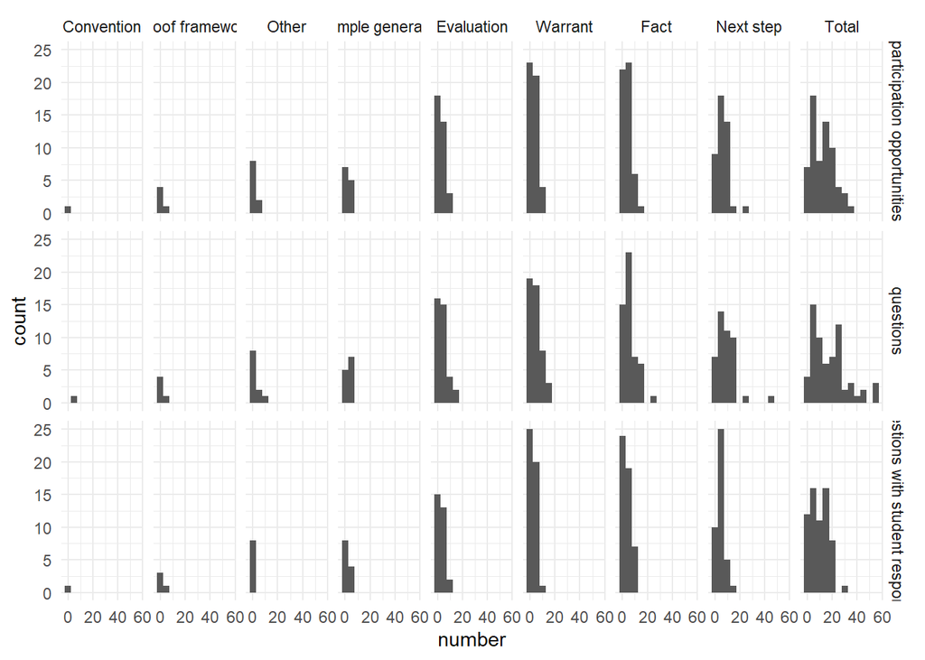

```r
plot_summary(counts_by_lecture_inc_totals_noAU)
```

# Drawing the comparison

## Questions by category

```r
comparison_of_counts <- bind_rows(
  "Kinnear et al." = counts_by_lecture_inc_totals_noAU,
  "Paoletti et al." = paoletti_code_counts %>% rename(course = Lecturer),
  .id = "Study"
  )
```

```r
comparison_of_total_qs <- comparison_of_counts %>%
  #filter(code_name %in% c("Proof framework", "Convention", "Total")) %>%
  select(Study, code_name, num_q) %>%
  group_by(Study, code_name) %>%
  tally(num_q, name = "total_qs")

comparison_of_total_qs %>%
  pivot_wider(names_from = "Study", values_from = "total_qs") %>%
  arrange(code_name == "Total", code_name) %>%
  rename(`Question category` = code_name) %>%
  basic_kable() %>%
  add_header_above(c(" " = 1, "Total number of questions" = 2))
```

| Question category | Total number of questions Kinnear et al. | Total number of questions Paoletti et al. |
| --- | --- | --- |
| Convention | 3 | 27 |
| Evaluation | 162 | 34 |
| Example generation | 40 | NA |
| Fact | 291 | 289 |
| Next step | 401 | 117 |
| Other | 27 | 59 |
| Proof framework | 8 | 31 |
| Warrant | 238 | 62 |
| Total | 1170 | 619 |

Here we show these counts as proportions, ordered by the frequency in the Paoletti et al. data:

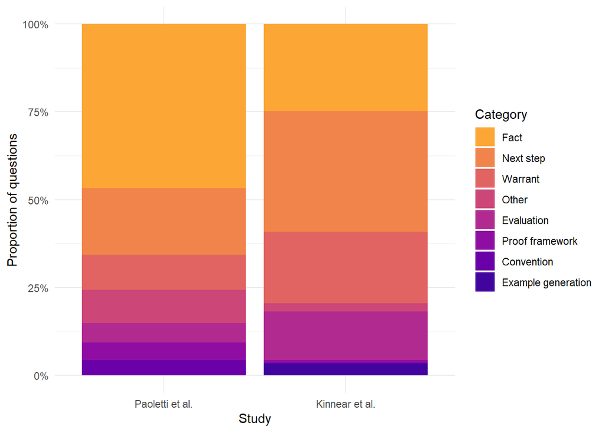

```r
# Produce a list of codes ordered by the frequency of appearance in the Paoletti et al. data
paoletti_frequency_order <- paoletti_code_counts %>%
  filter(code_name != "Total") %>%
  group_by(code_name) %>%
  tally(num_q) %>%
  arrange(-n) %>%
  select(code_name) %>%
  deframe()

comparison_of_total_qs %>%
  filter(code_name != "Total") %>%
  # Group the smaller categories with "Other"
  #mutate(code_name = fct_other(code_name, keep = c("Fact", "Next step", "Warrant", "Evaluation"))) %>%
  # Fix the order that things appear in
  #mutate(code_name = fct_relevel(code_name, "Fact", "Next step", "Warrant", "Evaluation", "Other")) %>%
  mutate(code_name = fct_relevel(code_name, paoletti_frequency_order)) %>%
  ggplot(aes(
    x = reorder(Study, desc(Study)), # put the studies in chronological order
    y = total_qs,
    fill = code_name,
  )) +
  geom_bar(position = "fill", stat = "identity") +
  scale_fill_viridis_d("Category", begin = 0.1, end = 0.8, option = "plasma", direction = -1) +
  scale_y_continuous(labels = scales::percent) +
  labs(x = "Study", y = "Proportion of questions")
```

```r
ggsave("figs/FIG_Paoletti_comparison_proportions.pdf",width=15,height=8,units="cm",dpi=300)
```

This shows each of the lectures as individual points:

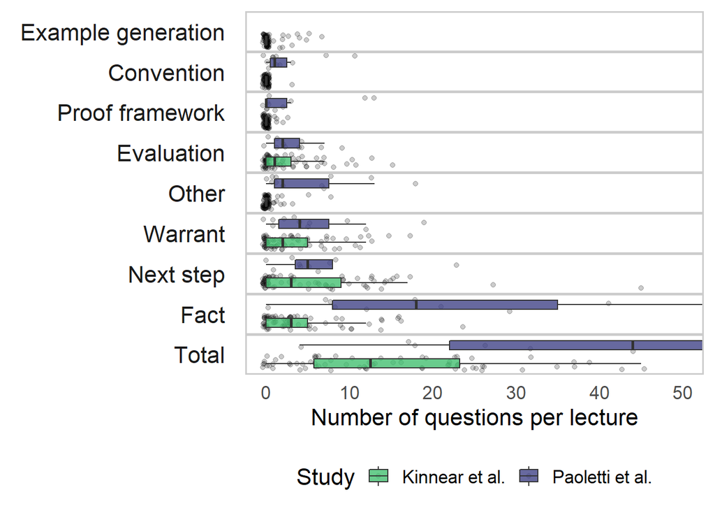

```r
comparison_of_counts %>%
  mutate(
    code_name = fct_reorder(code_name, num_q, .fun = max, .desc = FALSE)
  ) %>%
  ggplot(aes(y = Study,
             x = num_q)) +
  facet_grid(rows = vars(code_name),
             switch = "both") +
  #aes(fill = study, alpha = ifelse(study=="Kinnear", 1, 0.5)) +
  aes(fill = Study) +
  geom_jitter(alpha = 0.2) +
  geom_boxplot(width = 0.5, alpha = 0.8, outlier.shape = NA) +
  scale_fill_viridis_d(begin = 0.2, end = 0.7, direction = -1) +
  #stat_summary(fun=mean, geom="point", shape=8, size=6, colour = "red", alpha = 1, position = position_nudge(x = 0))+
  coord_cartesian(xlim=c(0, 50)) +
  #coord_flip() +
  theme_minimal(base_size = 16) +
  theme(strip.text=element_text(size=16),
        panel.border = element_rect(color = "#cccccc", fill = NA, size = 1),
        panel.spacing = unit(0, "lines"),
        strip.text.y.left = element_text(angle = 0, hjust = 1),
        strip.placement = "outside",
        axis.text.x=element_text(angle=0),
        #axis.text.y=element_text(size=12),
        axis.text.y=element_blank(),
        panel.grid.major = element_blank(),
        panel.grid.minor = element_blank(),
        legend.position = "bottom") +
  labs(y = NULL,
       x = "Number of questions per lecture")
```

```r
ggsave("figs/FIG_Paoletti_comparison.pdf",width=30,height=15,units="cm",dpi=300)
```

Summary stats about the total number of questions per lecture:

```r
bind_rows(
  "Kinnear et al." = counts_by_lecture_inc_totals_noAU %>%
    filter(code_name == "Total") %>%
    select(number = num_q) %>%
      summarise(
        n = n(),
        min = min(number),
        max = max(number),
        median = median(number),
        mean = mean(number),
        sd = sd(number),
      ),
  "Paoletti et al." = paoletti_data %>%
      select(number = Total) %>%
      summarise(
        n = n(),
        min = min(number),
        max = max(number),
        median = median(number),
        mean = mean(number),
        sd = sd(number),
      ),
  .id = "Study"
  ) %>%
  basic_kable(booktabs = T)
```

| Study | n | min | max | median | mean | sd |
| --- | --- | --- | --- | --- | --- | --- |
| Kinnear et al. | 72 | 0 | 56 | 12.5 | 16.25000 | 14.14786 |
| Paoletti et al. | 11 | 4 | 202 | 44.0 | 56.27273 | 54.95469 |